# Tweet analysis

Tijs Van den Heuvel

10/15/2020

# Tweet sentiment analysis and emoji prediction

The purpose of this project is to try and predict an emoji based on text.

It would be great if an algorithm could suggest some emojis based on a different piece of text.

The data set consists of a collection of tweets with at least one emoji.

[data source](https://www.kaggle.com/rexhaif/emojifydata-en)

The data is gathered, selected and reformatted by *Daniil Larionov* from the *ArchiveTeam Twitter data* source

I transformed this data to turn it into a data table in this jupyter notebook: preprocess with the use of PySpark and regex - this transformation process took a lot of work to make fast enough for large data sets - so I did it for 10 and 165 tweets to get started - I did some initial experimentation and data cleaning with the 10 tweets set - then I tried to create and run a model with the 165 tweets set - when that model worked (with an accuracy of 18%) I proceeded to fix the pre-processor & get the entire data set

```r
#tweetDT <- fread("./data/reduced_tweets_single.csv")
#tweetDT <- fread("./data/165tweets.csv")
tweetDT <- fread("./data/tweets_full_v2.csv")
nrow(tweetDT)
```

```
## [1] 2160892
```

## a sample of the tweets

```r
tweetDT[sample(1:.N,3)]
```

```
##                                                                                       text
## 1:    My brother got suspended from the bus So I had to take him home for almost two weeks
## 2:             140218 Polaroid do Yuta Taeil e Winwin entregue no NCT Sweet Valentines Day
## 3: FRIDA was RESCUED  this stunning girl escaped the gas chamber  thanks for your rts  h …
##                     emoji
## 1: face_with_tears_of_joy
## 2: face_with_tears_of_joy
## 3:              red_heart
```

## clean text

- remove all non ascii characters
- remove numbers
- remove words of length 1
- merge multiple spaces
- remove trailing spaces
- to lower case

> some of these steps could remove too much information, can be revised

> remove trailing space

> do this is fewer steps because this is slow

```r
tweetDT$text<-gsub('[^\x01-\x7F]',' ',tweetDT$text)
tweetDT$text<-gsub('[0-9]+',' ',tweetDT$text)
tweetDT$text<-gsub('\\b\\w{1}\\s','',tweetDT$text)
tweetDT$text<-gsub('\\s+',' ',tweetDT$text)
tweetDT$text<-gsub(' $','',tweetDT$text)
tweetDT$text<-tolower(tweetDT$text)
```

```r
tweetDT[sample(1:.N,10)]
```

```
##                                                                                                text
##  1:                                                                              look that tan glow
##  2:                                                         we not secret we just not yall business
##  3: round army time to attack has voted more votes than us on the past hour get this tweet to repli
##  4:                                                        want to hug yoongi right now please help
##  5:                                     transmutant buttuhpawn governor of neoconfederacy alt chaos
##  6:                   gave us some fast facts on topic she knows way too much about animal intimacy
##  7:                                                  puppet threw grgrma prison hide no originating
##  8:                          so my mom been stuck with immigration for the past hour in the airport
##  9:                                                  thank you bro cant wait to shoot skit with you
## 10:                                                  happy valentines day whats your favorite track
##                             emoji
##  1:                      sparkles
##  2: rolling_on_the_floor_laughing
##  3:                 flexed_biceps
##  4:            loudly_crying_face
##  5:                   female_sign
##  6:        face_with_tears_of_joy
##  7: backhand_index_pointing_right
##  8:        face_with_rolling_eyes
##  9:                     red_heart
## 10:                    two_hearts
```

## convert to Corpus to us tm package

- text cleaning can be done with regex in data table
- I could use the tm package if I would want to analyse the data in a different way

```r
corp = VCorpus(VectorSource(tweetDT$text))
writeLines(as.character(corp[[1]]))

corp <- tm_map(corp, removePunctuation)
corp <- tm_map(corp,content_transformer(tolower))

removeChar <- content_transformer(function(x, pattern) {return (gsub(pattern," ", x))})

corp <- tm_map(corp, removeChar,"%")
```

[output not shown]

## distribution of number of words in a tweet

```r
tweetDT$text %>% strsplit(" ") %>% sapply(length) %>% summary()
```

```
##    Min. 1st Qu.  Median    Mean 3rd Qu.    Max.
##    0.00    6.00   10.00   10.64   15.00   31.00
```

## how many different emoji’s are present

```r
emoji_count <- unique(tweetDT$emoji)%>%length()
emoji_count
```

```
## [1] 49
```

## Text classification with Tensorflow for R

- here I start with some tensorflow tutorial
  - [tutorial](https://tensorflow.rstudio.com/tutorials/beginners/basic-ml/tutorial_basic_text_classification/)
- the input is the text of the tweet
- the output should be the emoji
- a neural network takes in tensors (matrix) and not text so I needed to prepare the data

```r
library(keras)
library(dplyr)
```

```r
library(ggplot2)
library(purrr)
```

### prepare the input data

- the tweets must be converted to tensors to use in NN
- create a dictionary & represent each of the 10,000 most common words by an integer
- you could create a very sparse 1,0000D vector but that’s too memory intensive (one hot)
- alternative solution from tutorial:
  - pad the arrays so they all have same length
  - create integer tensor of shape `num_examples * max_length`
  - use an embedding layer capable of handling this shape as first layer
- `adapt` the text vectorization layer to learn about unique words in our data set

```r
num_words <- 10000
max_length <- 50
text_vectorization <- layer_text_vectorization(
  max_tokens = num_words,
  output_sequence_length = max_length,
)
text_vectorization %>% adapt(tweetDT$text)
```

show vocabulary

```r
get_vocabulary(text_vectorization)%>%sample(10)
```

[output not shown]

show how text vectorization layer transforms input

```r
text_vectorization(matrix(tweetDT$text[1], ncol = 1))
```

[output not shown]

### prepare the output data

- I searched a long time how to encode the emojis
- the emojis have to be encoded as a vector
- one hot is a good method
- keras had built in function: to_categorical but it needs integer input
- convert labels to integers
- first column is entirely empty so I remove it
- how many emojis are there -> size of final layer
- create an emoji dictionary to find which number maps to which emoji after prediction

```r
emoji_int <- match(tweetDT$emoji,unique(tweetDT$emoji))

one_hot_emoji <- to_categorical(emoji_int)
one_hot_emoji <- one_hot_emoji[,2:(emoji_count+1)]

emoji_dict <- tweetDT$emoji%>%unique()
```

### split the dataset into training & testing

- 80% training, 20% testing, arbitrarily chosen

```r
training_id <- sample.int(nrow(tweetDT), size = nrow(tweetDT)*0.8)
training <- tweetDT[training_id,]
testing <- tweetDT[-training_id,]
oh_train <-one_hot_emoji[training_id,]
oh_test <- one_hot_emoji[-training_id,]
nrow(training)
```

```
## [1] 1728713
```

```r
nrow(oh_train)
```

```
## [1] 1728713
```

```r
nrow(testing)
```

```
## [1] 432179
```

```r
nrow(oh_test)
```

```
## [1] 432179
```

### build the model

- how many layers?
- how many hidden units?
- what types of building blocks?

model 1 - accuracy on test set of 29% - loss of 2.783

```r
input <- layer_input(shape = c(1), dtype = "string")

output <- input %>%
  text_vectorization() %>%
  layer_embedding(input_dim = num_words + 1, output_dim = 16) %>%
  layer_global_average_pooling_1d() %>%
  layer_dense(units = 16, activation = "relu") %>%
  layer_dropout(0.5) %>%
  layer_dense(units = emoji_count, activation = "softmax")

model <- keras_model(input, output)
```

model 2 - add an extra layer - accuracy on test set is 33% - loss is 2.6548331

```r
input <- layer_input(shape = c(1), dtype = "string")

output <- input %>%
  text_vectorization() %>%
  layer_embedding(input_dim = num_words + 1, output_dim = 16) %>%
  layer_global_average_pooling_1d() %>%
  layer_dense(units = 16, activation = "relu") %>%
  layer_dense(units = 16, activation = "relu") %>%
  layer_dropout(0.2) %>%
  layer_dense(units = emoji_count, activation = "softmax")

model <- keras_model(input, output)
```

model 3 - add an extra layer - 2 dropout layers - double the size of the layers: 16 is small to go from 50 tot 50 - accuracy on test set is 0.34 - loss is 2.5792720 - the more complex network is only slightly more performant

```r
input <- layer_input(shape = c(1), dtype = "string")

output <- input %>%
  text_vectorization() %>%
  layer_embedding(input_dim = num_words + 1, output_dim = 16) %>%
  layer_global_average_pooling_1d() %>%
  layer_dense(units = 32, activation = "relu") %>%
  layer_dropout(0.1) %>%
  layer_dense(units = 32, activation = "relu") %>%
  layer_dropout(0.1) %>%
  layer_dense(units = 32, activation = "relu") %>%
  layer_dense(units = emoji_count, activation = "softmax")

model <- keras_model(input, output)
```

model 4 -the input and output are both size 50 so let’s make the middle layers also size 50 - 2 dense layers - 1 small dropout - accuracy on test set is 0.3578 - loss is 2.5344746

```r
input <- layer_input(shape = c(1), dtype = "string")

output <- input %>%
  text_vectorization() %>%
  layer_embedding(input_dim = num_words + 1, output_dim = 16) %>%
  layer_global_average_pooling_1d() %>%
  layer_dense(units = 50, activation = "relu") %>%
  layer_dense(units = 50, activation = "relu") %>%
  layer_dropout(0.2) %>%
  layer_dense(units = emoji_count, activation = "softmax")

model <- keras_model(input, output)
```

model 5 - 50 is perhaps a little big - lets try a deeper more slender model - accuracy on test set is 0.3398407 - loss is 2.6135445

```r
input <- layer_input(shape = c(1), dtype = "string")

output <- input %>%
  text_vectorization() %>%
  layer_embedding(input_dim = num_words + 1, output_dim = 16) %>%
  layer_global_average_pooling_1d() %>%
  layer_dense(units = 32, activation = "relu") %>%
  layer_dense(units = 32, activation = "relu") %>%
  layer_dropout(0.1) %>%
  layer_dense(units = 32, activation = "relu") %>%
  layer_dropout(0.1) %>%
  layer_dense(units = 32, activation = "relu") %>%
  layer_dropout(0.1) %>%
  layer_dense(units = emoji_count, activation = "softmax")

model <- keras_model(input, output)
```

### loss function and optimizer

- the tutorial uses binary_crossentropy but our variables are categorical

```r
model %>% compile(
  optimizer = 'adam',
  loss = 'categorical_crossentropy',
  metrics = list('accuracy')
)
```

### Train the model

```r
history <- model %>% fit(
  training$text,
  oh_train,
  epochs = 100,
  batch_size = 512,
  validation_split = 0.2,
  verbose=2
)
```

### evaluate model

```r
results <- model %>% evaluate(testing$text, oh_test, verbose = 0)
results
```

```
##      loss  accuracy
## 2.6178248 0.3387439
```

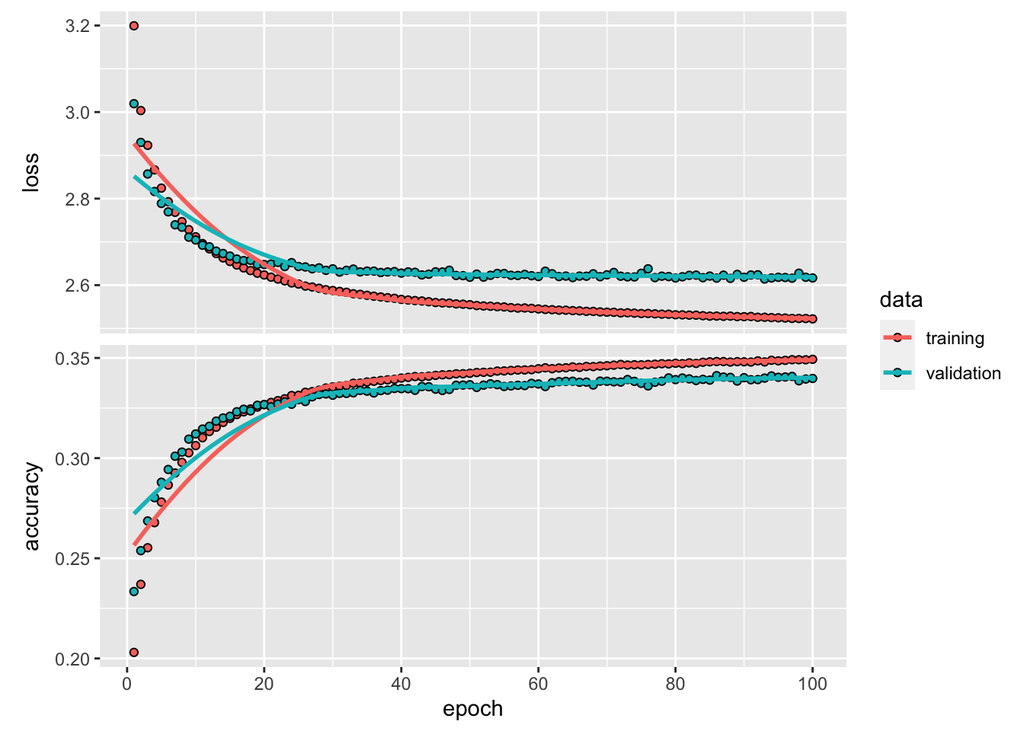

```r
plot(history)
```

```r
testing[sample(1:.N,10)]
```

```
##                                                                                                        text
##  1:                                                     nuest concert double you in seoul jr focus full ver
##  2:                            please make sure every fellow army has seen this new or old plz rewatch this
##  3:                                                                        cant believe its been years yall
##  4:                                                       ive been retweeting this everytime see it love it
##  5:                                                                    hello we introduce you our jeon cena
##  6:                                                                      nominate as favorite female singer
##  7:                                                               digital song of the year goes to queen iu
##  8:                 this time next week ill be back in disneyland paris cant believe the th anniversary was
##  9: we should all take moment and pay tribute to the actual footage of this glorious jodie foster interview
## 10:                              nobody told me it would hurt this bad when you left miss you so much dutch
##                             emoji
##  1: backhand_index_pointing_right
##  2:            loudly_crying_face
##  3:                     male_sign
##  4:                    two_hearts
##  5:  smiling_face_with_sunglasses
##  6:                  glowing_star
##  7:                    heart_suit
##  8:                      sparkles
##  9:                hundred_points
## 10:            loudly_crying_face
```

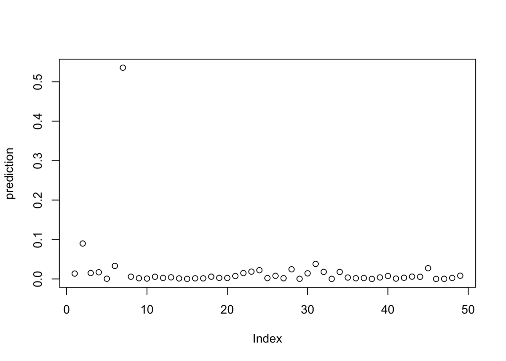

```r
id <-10
prediction <- predict(model,testing$text[id])[1,]
predicted_int <- which.max(prediction)
predicted_emoji <- emoji_dict[predicted_int]

plot(prediction)
```

```r
print(paste("predicted:",predicted_emoji))
```

```
## [1] "predicted: face_with_tears_of_joy"
```

```r
print(paste("true:",testing$emoji[id]))
```

```
## [1] "true: weary_face"
```

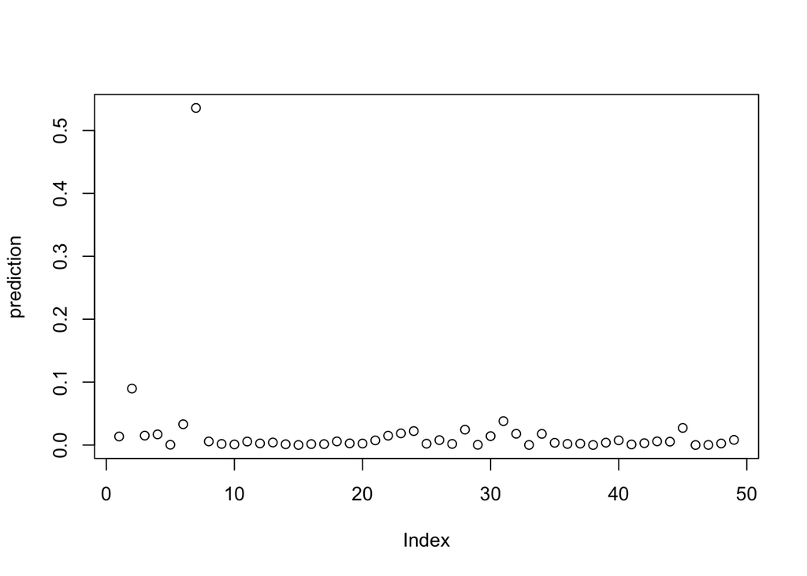

```r
plot(prediction)
```